# Exploratory Data Analysis

For this notebook we will explore a dataset in class. As a reference point, this notebook goes over several great EDA principles: https://nbviewer.jupyter.org/github/PBPatil/Exploratory_Data_Analysis-Wine_Quality_Dataset/blob/master/winequality_white.ipynb

The purpose of this notebook is to explore the avaiation safety dataset from Kaggle ([link](https://www.kaggle.com/dhruvagg/aviation-safety)).

```python
import pandas as pd
import seaborn as sns
```

```python
import matplotlib.pyplot as plt
```

```python
df = pd.read_csv('aviation_safety.csv')
```

```python
df.head()
```

|  | Unnamed: 0 | airline | avail_seat_km_per_week | incidents_85_99 | fatal_accidents_85_99 | fatalities_85_99 | incidents_00_14 | fatal_accidents_00_14 | fatalities_00_14 |
| --- | --- | --- | --- | --- | --- | --- | --- | --- | --- |
| 0 | NaN | Aer Lingus | 320906734 | 2 | 0 | 0 | 0 | 0 | 0 |
| 1 | NaN | Aeroflot* | 1197672318 | 76 | 14 | 128 | 6 | 1 | 88 |
| 2 | NaN | Aerolineas Argentinas | 385803648 | 6 | 0 | 0 | 1 | 0 | 0 |
| 3 | NaN | Aeromexico* | 596871813 | 3 | 1 | 64 | 5 | 0 | 0 |
| 4 | NaN | Air Canada | 1865253802 | 2 | 0 | 0 | 2 | 0 | 0 |

```python
df.dtypes
```

```
Unnamed: 0                float64
airline                    object
avail_seat_km_per_week      int64
incidents_85_99             int64
fatal_accidents_85_99       int64
fatalities_85_99            int64
incidents_00_14             int64
fatal_accidents_00_14       int64
fatalities_00_14            int64
dtype: object
```

```python
df = df.drop(columns='Unnamed: 0')
```

```python
df.sample(10)
```

|  | airline | avail_seat_km_per_week | incidents_85_99 | fatal_accidents_85_99 | fatalities_85_99 | incidents_00_14 | fatal_accidents_00_14 | fatalities_00_14 |
| --- | --- | --- | --- | --- | --- | --- | --- | --- |
| 31 | Korean Air | 1734522605 | 12 | 5 | 425 | 1 | 0 | 0 |
| 18 | COPA | 550491507 | 3 | 1 | 47 | 0 | 0 | 0 |
| 49 | Thai Airways | 1702802250 | 8 | 4 | 308 | 2 | 1 | 1 |
| 25 | Gulf Air | 301379762 | 1 | 0 | 0 | 3 | 1 | 143 |
| 21 | El Al | 335448023 | 1 | 1 | 4 | 1 | 0 | 0 |
| 44 | Sri Lankan / AirLanka | 325582976 | 2 | 1 | 14 | 4 | 0 | 0 |
| 12 | Austrian Airlines | 358239823 | 1 | 0 | 0 | 1 | 0 | 0 |
| 39 | SAS* | 682971852 | 5 | 0 | 0 | 6 | 1 | 110 |
| 35 | Pakistan International | 348563137 | 8 | 3 | 234 | 10 | 2 | 46 |
| 55 | Xiamen Airlines | 430462962 | 9 | 1 | 82 | 2 | 0 | 0 |

```python
df.columns
```

```
Index(['airline', 'avail_seat_km_per_week', 'incidents_85_99',
       'fatal_accidents_85_99', 'fatalities_85_99', 'incidents_00_14',
       'fatal_accidents_00_14', 'fatalities_00_14'],
      dtype='object')
```

```python
df.shape
```

```
(56, 8)
```

```python
df['airline'].unique()
```

```
array(['Aer Lingus', 'Aeroflot*', 'Aerolineas Argentinas', 'Aeromexico*',
       'Air Canada', 'Air France', 'Air India*', 'Air New Zealand*',
       'Alaska Airlines*', 'Alitalia', 'All Nippon Airways', 'American*',
       'Austrian Airlines', 'Avianca', 'British Airways*',
       'Cathay Pacific*', 'China Airlines', 'Condor', 'COPA',
       'Delta / Northwest*', 'Egyptair', 'El Al', 'Ethiopian Airlines',
       'Finnair', 'Garuda Indonesia', 'Gulf Air', 'Hawaiian Airlines',
       'Iberia', 'Japan Airlines', 'Kenya Airways', 'KLM*', 'Korean Air',
       'LAN Airlines', 'Lufthansa*', 'Malaysia Airlines',
       'Pakistan International', 'Philippine Airlines', 'Qantas*',
       'Royal Air Maroc', 'SAS*', 'Saudi Arabian', 'Singapore Airlines',
       'South African', 'Southwest Airlines', 'Sri Lankan / AirLanka',
       'SWISS*', 'TACA', 'TAM', 'TAP - Air Portugal', 'Thai Airways',
       'Turkish Airlines', 'United / Continental*',
       'US Airways / America West*', 'Vietnam Airlines',
       'Virgin Atlantic', 'Xiamen Airlines'], dtype=object)
```

```python
df.info()
```

```
<class 'pandas.core.frame.DataFrame'>
RangeIndex: 56 entries, 0 to 55
Data columns (total 8 columns):
 #   Column                  Non-Null Count  Dtype
---  ------                  --------------  -----
 0   airline                 56 non-null     object
 1   avail_seat_km_per_week  56 non-null     int64
 2   incidents_85_99         56 non-null     int64
 3   fatal_accidents_85_99   56 non-null     int64
 4   fatalities_85_99        56 non-null     int64
 5   incidents_00_14         56 non-null     int64
 6   fatal_accidents_00_14   56 non-null     int64
 7   fatalities_00_14        56 non-null     int64
dtypes: int64(7), object(1)
memory usage: 3.6+ KB
```

```python
df.isnull().sum()
```

```
airline                   0
avail_seat_km_per_week    0
incidents_85_99           0
fatal_accidents_85_99     0
fatalities_85_99          0
incidents_00_14           0
fatal_accidents_00_14     0
fatalities_00_14          0
dtype: int64
```

```python
df['airline'].value_counts()
```

```
Singapore Airlines            1
All Nippon Airways            1
Garuda Indonesia              1
Alitalia                      1
Austrian Airlines             1
US Airways / America West*    1
China Airlines                1
SWISS*                        1
Air New Zealand*              1
Thai Airways                  1
Kenya Airways                 1
Virgin Atlantic               1
Royal Air Maroc               1
LAN Airlines                  1
TACA                          1
Aer Lingus                    1
Korean Air                    1
SAS*                          1
Xiamen Airlines               1
Pakistan International        1
Southwest Airlines            1
Hawaiian Airlines             1
KLM*                          1
Egyptair                      1
British Airways*              1
TAP - Air Portugal            1
Air Canada                    1
Alaska Airlines*              1
Finnair                       1
Saudi Arabian                 1
Vietnam Airlines              1
COPA                          1
Japan Airlines                1
Air India*                    1
Qantas*                       1
Delta / Northwest*            1
Aeromexico*                   1
Avianca                       1
El Al                         1
Sri Lankan / AirLanka         1
TAM                           1
Turkish Airlines              1
Iberia                        1
Cathay Pacific*               1
Aerolineas Argentinas         1
Lufthansa*                    1
Ethiopian Airlines            1
South African                 1
Philippine Airlines           1
American*                     1
Gulf Air                      1
Aeroflot*                     1
Malaysia Airlines             1
Condor                        1
United / Continental*         1
Air France                    1
Name: airline, dtype: int64
```

```python
df.head()
```

|  | airline | avail_seat_km_per_week | incidents_85_99 | fatal_accidents_85_99 | fatalities_85_99 | incidents_00_14 | fatal_accidents_00_14 | fatalities_00_14 |
| --- | --- | --- | --- | --- | --- | --- | --- | --- |
| 0 | Aer Lingus | 320906734 | 2 | 0 | 0 | 0 | 0 | 0 |
| 1 | Aeroflot* | 1197672318 | 76 | 14 | 128 | 6 | 1 | 88 |
| 2 | Aerolineas Argentinas | 385803648 | 6 | 0 | 0 | 1 | 0 | 0 |
| 3 | Aeromexico* | 596871813 | 3 | 1 | 64 | 5 | 0 | 0 |
| 4 | Air Canada | 1865253802 | 2 | 0 | 0 | 2 | 0 | 0 |

## Observations

- Each row is unique and represents one airline.
- No NaN values
- Two time periods

Questions:

- Which is the worst airline in terms of fatalities?
- Which airline has the most incidents?
- Which has the most miles traveled?

## Heatmap

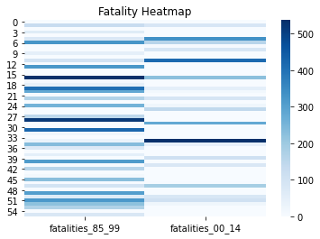

```python
plt.title('Fatality Heatmap')
sns.heatmap(df[['fatalities_85_99','fatalities_00_14']], cmap='Blues')
```

```python
df.iloc[34]
```

```
airline                   Malaysia Airlines
avail_seat_km_per_week           1039171244
incidents_85_99                           3
fatal_accidents_85_99                     1
fatalities_85_99                         34
incidents_00_14                           3
fatal_accidents_00_14                     2
fatalities_00_14                        537
Name: 34, dtype: object
```

## Observations

- Fatalities lowered from 85-99
- Malayasian airlines was the highest fatality in 2000-2014
- Some airlines got worse, but most got better in terms of fatalities

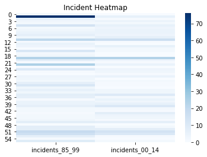

```python
plt.title('Incident Heatmap')
sns.heatmap(df[['incidents_85_99','incidents_00_14']], cmap='Blues')
```

```python
df.iloc[1]
```

```
airline                    Aeroflot*
avail_seat_km_per_week    1197672318
incidents_85_99                   76
fatal_accidents_85_99             14
fatalities_85_99                 128
incidents_00_14                    6
fatal_accidents_00_14              1
fatalities_00_14                  88
Name: 1, dtype: object
```

## Correlation Matrix

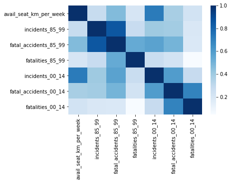

```python
sns.heatmap(df.corr(), cmap='Blues')
```

## Observations

- Fatalities from 85-99 and 00-14 are not correlated.
- The more kms an airlines the more incidents they can expect.
- Hypothesis: Accidents from 00-14 are *more fatal* than from 85-99.

```python
df['fatalities_85_99'].sum() / df['fatal_accidents_85_99'].sum()
```

```
51.59836065573771
```

```python
df['fatalities_00_14'].sum() / df['fatal_accidents_00_14'].sum()
```

```
84.02702702702703
```

Observation: There were more fatalities per fatal accident from 00-14 than 85-99.

```python
df.head()
```

|  | airline | avail_seat_km_per_week | incidents_85_99 | fatal_accidents_85_99 | fatalities_85_99 | incidents_00_14 | fatal_accidents_00_14 | fatalities_00_14 |
| --- | --- | --- | --- | --- | --- | --- | --- | --- |
| 0 | Aer Lingus | 320906734 | 2 | 0 | 0 | 0 | 0 | 0 |
| 1 | Aeroflot* | 1197672318 | 76 | 14 | 128 | 6 | 1 | 88 |
| 2 | Aerolineas Argentinas | 385803648 | 6 | 0 | 0 | 1 | 0 | 0 |
| 3 | Aeromexico* | 596871813 | 3 | 1 | 64 | 5 | 0 | 0 |
| 4 | Air Canada | 1865253802 | 2 | 0 | 0 | 2 | 0 | 0 |

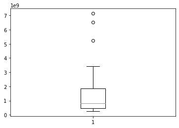

```python
plt.boxplot(df['avail_seat_km_per_week'])
plt.show()
```

```python
df.sort_values('avail_seat_km_per_week', ascending=False)
```

|  | airline | avail_seat_km_per_week | incidents_85_99 | fatal_accidents_85_99 | fatalities_85_99 | incidents_00_14 | fatal_accidents_00_14 | fatalities_00_14 |
| --- | --- | --- | --- | --- | --- | --- | --- | --- |
| 51 | United / Continental* | 7139291291 | 19 | 8 | 319 | 14 | 2 | 109 |
| 19 | Delta / Northwest* | 6525658894 | 24 | 12 | 407 | 24 | 2 | 51 |
| 11 | American* | 5228357340 | 21 | 5 | 101 | 17 | 3 | 416 |
| 33 | Lufthansa* | 3426529504 | 6 | 1 | 2 | 3 | 0 | 0 |
| 43 | Southwest Airlines | 3276525770 | 1 | 0 | 0 | 8 | 0 | 0 |
| 14 | British Airways* | 3179760952 | 4 | 0 | 0 | 6 | 0 | 0 |
| 5 | Air France | 3004002661 | 14 | 4 | 79 | 6 | 2 | 337 |
| 15 | Cathay Pacific* | 2582459303 | 0 | 0 | 0 | 2 | 0 | 0 |
| 52 | US Airways / America West* | 2455687887 | 16 | 7 | 224 | 11 | 2 | 23 |
| 41 | Singapore Airlines | 2376857805 | 2 | 2 | 6 | 2 | 1 | 83 |
| 50 | Turkish Airlines | 1946098294 | 8 | 3 | 64 | 8 | 2 | 84 |
| 37 | Qantas* | 1917428984 | 1 | 0 | 0 | 5 | 0 | 0 |
| 30 | KLM* | 1874561773 | 7 | 1 | 3 | 1 | 0 | 0 |
| 4 | Air Canada | 1865253802 | 2 | 0 | 0 | 2 | 0 | 0 |
| 10 | All Nippon Airways | 1841234177 | 3 | 1 | 1 | 7 | 0 | 0 |
| 31 | Korean Air | 1734522605 | 12 | 5 | 425 | 1 | 0 | 0 |
| 49 | Thai Airways | 1702802250 | 8 | 4 | 308 | 2 | 1 | 1 |
| 28 | Japan Airlines | 1574217531 | 3 | 1 | 520 | 0 | 0 | 0 |
| 47 | TAM | 1509195646 | 8 | 3 | 98 | 7 | 2 | 188 |
| 1 | Aeroflot* | 1197672318 | 76 | 14 | 128 | 6 | 1 | 88 |
| 27 | Iberia | 1173203126 | 4 | 1 | 148 | 5 | 0 | 0 |
| 34 | Malaysia Airlines | 1039171244 | 3 | 1 | 34 | 3 | 2 | 537 |
| 54 | Virgin Atlantic | 1005248585 | 1 | 0 | 0 | 0 | 0 | 0 |
| 32 | LAN Airlines | 1001965891 | 3 | 2 | 21 | 0 | 0 | 0 |
| 8 | Alaska Airlines* | 965346773 | 5 | 0 | 0 | 5 | 1 | 88 |
| 6 | Air India* | 869253552 | 2 | 1 | 329 | 4 | 1 | 158 |
| 40 | Saudi Arabian | 859673901 | 7 | 2 | 313 | 11 | 0 | 0 |
| 16 | China Airlines | 813216487 | 12 | 6 | 535 | 2 | 1 | 225 |
| 45 | SWISS* | 792601299 | 2 | 1 | 229 | 3 | 0 | 0 |
| 7 | Air New Zealand* | 710174817 | 3 | 0 | 0 | 5 | 1 | 7 |
| 9 | Alitalia | 698012498 | 7 | 2 | 50 | 4 | 0 | 0 |
| 39 | SAS* | 682971852 | 5 | 0 | 0 | 6 | 1 | 110 |
| 42 | South African | 651502442 | 2 | 1 | 159 | 1 | 0 | 0 |
| 53 | Vietnam Airlines | 625084918 | 7 | 3 | 171 | 1 | 0 | 0 |
| 48 | TAP - Air Portugal | 619130754 | 0 | 0 | 0 | 0 | 0 | 0 |
| 24 | Garuda Indonesia | 613356665 | 10 | 3 | 260 | 4 | 2 | 22 |
| 3 | Aeromexico* | 596871813 | 3 | 1 | 64 | 5 | 0 | 0 |
| 20 | Egyptair | 557699891 | 8 | 3 | 282 | 4 | 1 | 14 |
| 18 | COPA | 550491507 | 3 | 1 | 47 | 0 | 0 | 0 |
| 23 | Finnair | 506464950 | 1 | 0 | 0 | 0 | 0 | 0 |
| 26 | Hawaiian Airlines | 493877795 | 0 | 0 | 0 | 1 | 0 | 0 |
| 22 | Ethiopian Airlines | 488560643 | 25 | 5 | 167 | 5 | 2 | 92 |
| 55 | Xiamen Airlines | 430462962 | 9 | 1 | 82 | 2 | 0 | 0 |
| 17 | Condor | 417982610 | 2 | 1 | 16 | 0 | 0 | 0 |
| 36 | Philippine Airlines | 413007158 | 7 | 4 | 74 | 2 | 1 | 1 |
| 13 | Avianca | 396922563 | 5 | 3 | 323 | 0 | 0 | 0 |
| 2 | Aerolineas Argentinas | 385803648 | 6 | 0 | 0 | 1 | 0 | 0 |
| 12 | Austrian Airlines | 358239823 | 1 | 0 | 0 | 1 | 0 | 0 |
| 35 | Pakistan International | 348563137 | 8 | 3 | 234 | 10 | 2 | 46 |
| 21 | El Al | 335448023 | 1 | 1 | 4 | 1 | 0 | 0 |
| 44 | Sri Lankan / AirLanka | 325582976 | 2 | 1 | 14 | 4 | 0 | 0 |
| 0 | Aer Lingus | 320906734 | 2 | 0 | 0 | 0 | 0 | 0 |
| 25 | Gulf Air | 301379762 | 1 | 0 | 0 | 3 | 1 | 143 |
| 38 | Royal Air Maroc | 295705339 | 5 | 3 | 51 | 3 | 0 | 0 |
| 29 | Kenya Airways | 277414794 | 2 | 0 | 0 | 2 | 2 | 283 |
| 46 | TACA | 259373346 | 3 | 1 | 3 | 1 | 1 | 3 |

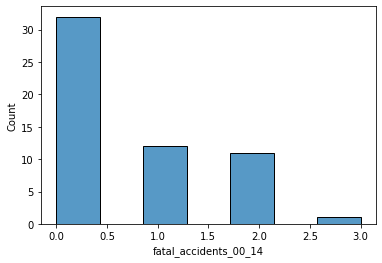

```python
sns.histplot(data=df, x='fatal_accidents_00_14')
```

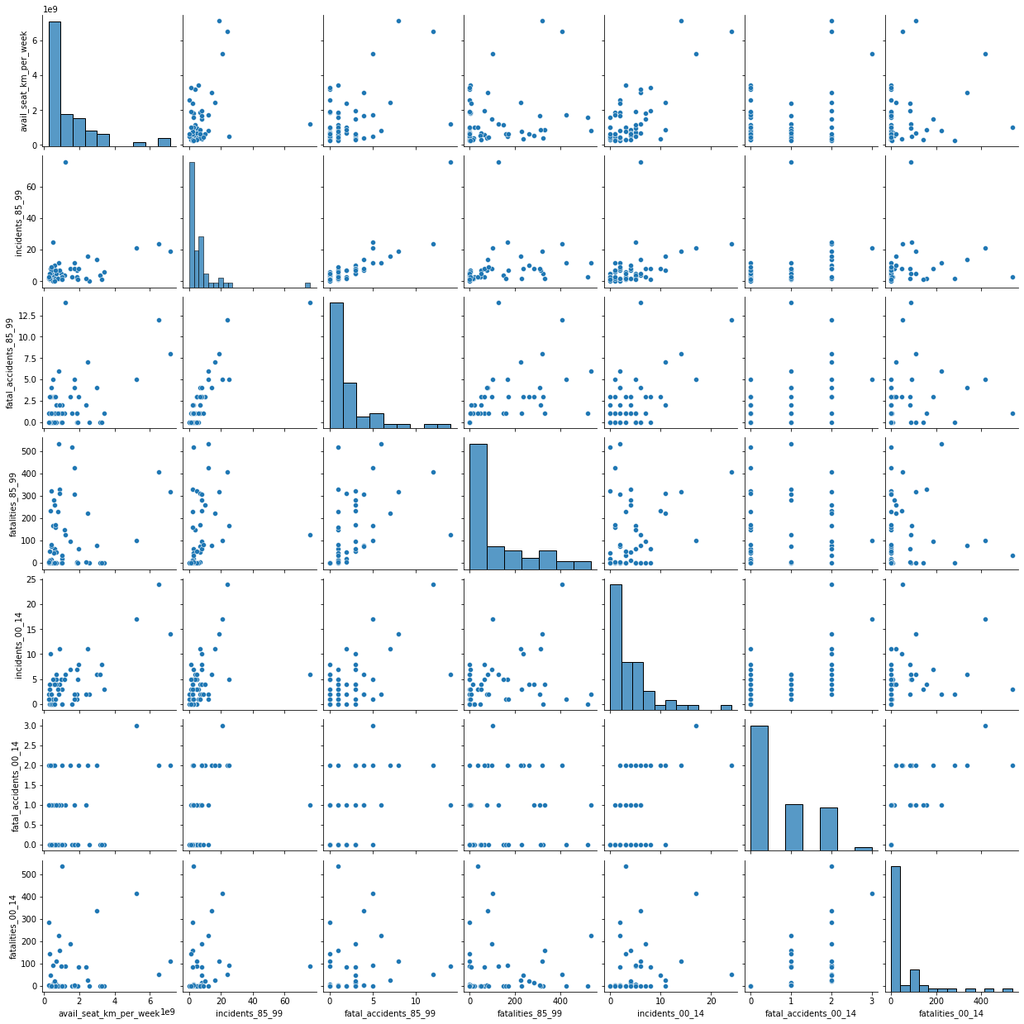

```python
sns.pairplot(df)
```

[figure not shown]

```python
sns.violinplot(data=df)
```